# Y Doesn’t Need to Be Normal - Only Errors Do

Author

SDC

## Introduction

This document demonstrates a key concept in linear regression: **the response variable Y does not need to be normally distributed**. What matters is that the **errors (residuals) are normally distributed**.

We’ll simulate data where Y is clearly bimodal (not normal), but the regression assumptions are perfectly satisfied.

## Setup

```r
library(ggplot2)
library(patchwork)
library(dplyr)

set.seed(123)
```

## Data Generation

```r
n <- 1000

# Create a predictor with two distinct groups (creates bimodal Y)
X <- c(rnorm(500, mean = 10, sd = 2),
       rnorm(500, mean = 30, sd = 2))

# True linear relationship with NORMALLY DISTRIBUTED ERRORS
true_beta0 <- 5
true_beta1 <- 2
errors <- rnorm(n, mean = 0, sd = 5)  # Normal errors

Y <- true_beta0 + true_beta1 * X + errors

# Create data frame
data <- data.frame(X = X, Y = Y)
```

## Fit the Model

```r
model <- lm(Y ~ X, data = data)
summary(model)
```

```
Call:
lm(formula = Y ~ X, data = data)

Residuals:
     Min       1Q   Median       3Q      Max
-15.5912  -3.4517  -0.0075   3.5776  16.8812

Coefficients:
            Estimate Std. Error t value Pr(>|t|)
(Intercept)  4.88653    0.35297   13.84   <2e-16 ***
X            2.01626    0.01571  128.30   <2e-16 ***
---
Signif. codes:  0 '***' 0.001 '**' 0.01 '*' 0.05 '.' 0.1 ' ' 1

Residual standard error: 5.048 on 998 degrees of freedom
Multiple R-squared:  0.9428,    Adjusted R-squared:  0.9428
F-statistic: 1.646e+04 on 1 and 998 DF,  p-value: < 2.2e-16
```

**Key Point**: The estimated slope is 2.016 vs true slope of 2 - nearly perfect!

## Diagnostic Visualizations

### Response Variable Y (NOT Normal)

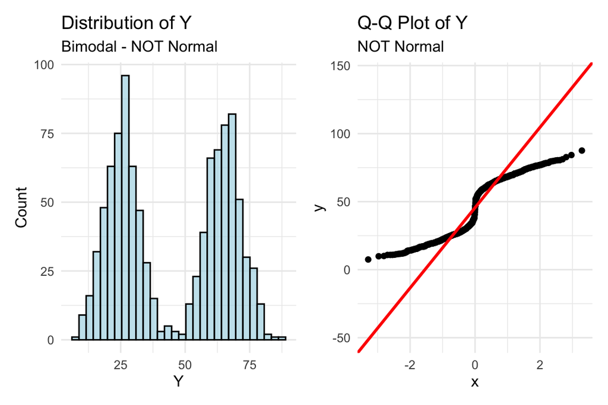

```r
# Distribution of Y
p1 <- ggplot(data, aes(x = Y)) +
  geom_histogram(bins = 30, fill = "lightblue", color = "black", alpha = 0.7) +
  labs(title = "Distribution of Y",
       subtitle = "Bimodal - NOT Normal",
       x = "Y", y = "Count") +
  theme_minimal()

# QQ plot of Y
p2 <- ggplot(data, aes(sample = Y)) +
  stat_qq() +
  stat_qq_line(color = "red", linewidth = 1) +
  labs(title = "Q-Q Plot of Y",
       subtitle = "NOT Normal") +
  theme_minimal()

p1 + p2
```

```r
# Shapiro-Wilk test on Y
shapiro_y <- shapiro.test(Y)
```

**Shapiro-Wilk test for Y**: p-value = 1.17e-26

This tiny p-value confirms Y is NOT normally distributed.

### Residuals (ARE Normal!)

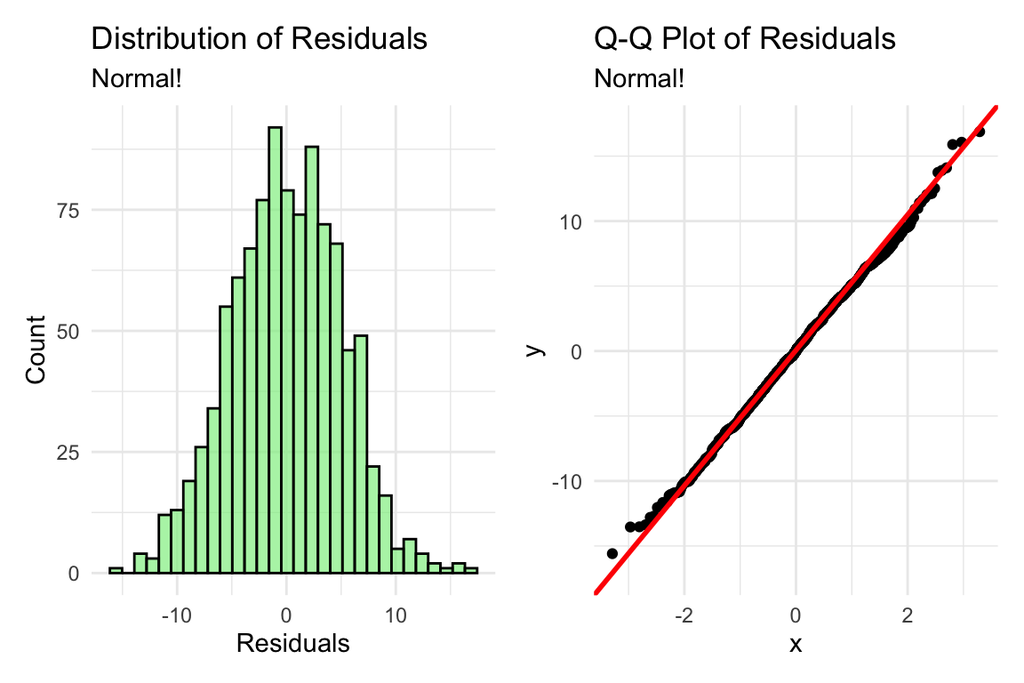

```r
# Add residuals and fitted values to data frame
data$residuals <- residuals(model)
data$fitted <- fitted(model)

# Distribution of residuals
p3 <- ggplot(data, aes(x = residuals)) +
  geom_histogram(bins = 30, fill = "lightgreen", color = "black", alpha = 0.7) +
  labs(title = "Distribution of Residuals",
       subtitle = "Normal!",
       x = "Residuals", y = "Count") +
  theme_minimal()

# QQ plot of residuals
p4 <- ggplot(data, aes(sample = residuals)) +
  stat_qq() +
  stat_qq_line(color = "red", linewidth = 1) +
  labs(title = "Q-Q Plot of Residuals",
       subtitle = "Normal!") +
  theme_minimal()

p3 + p4
```

```r
# Shapiro-Wilk test on residuals
shapiro_resid <- shapiro.test(residuals(model))
```

**Shapiro-Wilk test for residuals**: p-value = 0.591

This large p-value indicates residuals are consistent with normality.

### Residuals vs Fitted Values

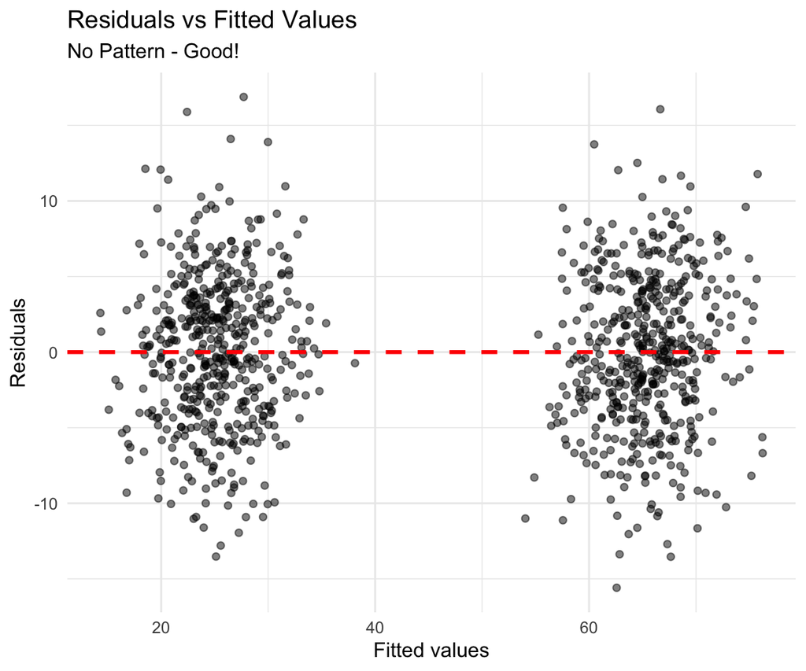

```r
ggplot(data, aes(x = fitted, y = residuals)) +
  geom_point(alpha = 0.5) +
  geom_hline(yintercept = 0, color = "red", linetype = "dashed", linewidth = 1) +
  labs(title = "Residuals vs Fitted Values",
       subtitle = "No Pattern - Good!",
       x = "Fitted values", y = "Residuals") +
  theme_minimal()
```

No systematic pattern in residuals → regression assumptions satisfied!

## The Regression Works Perfectly

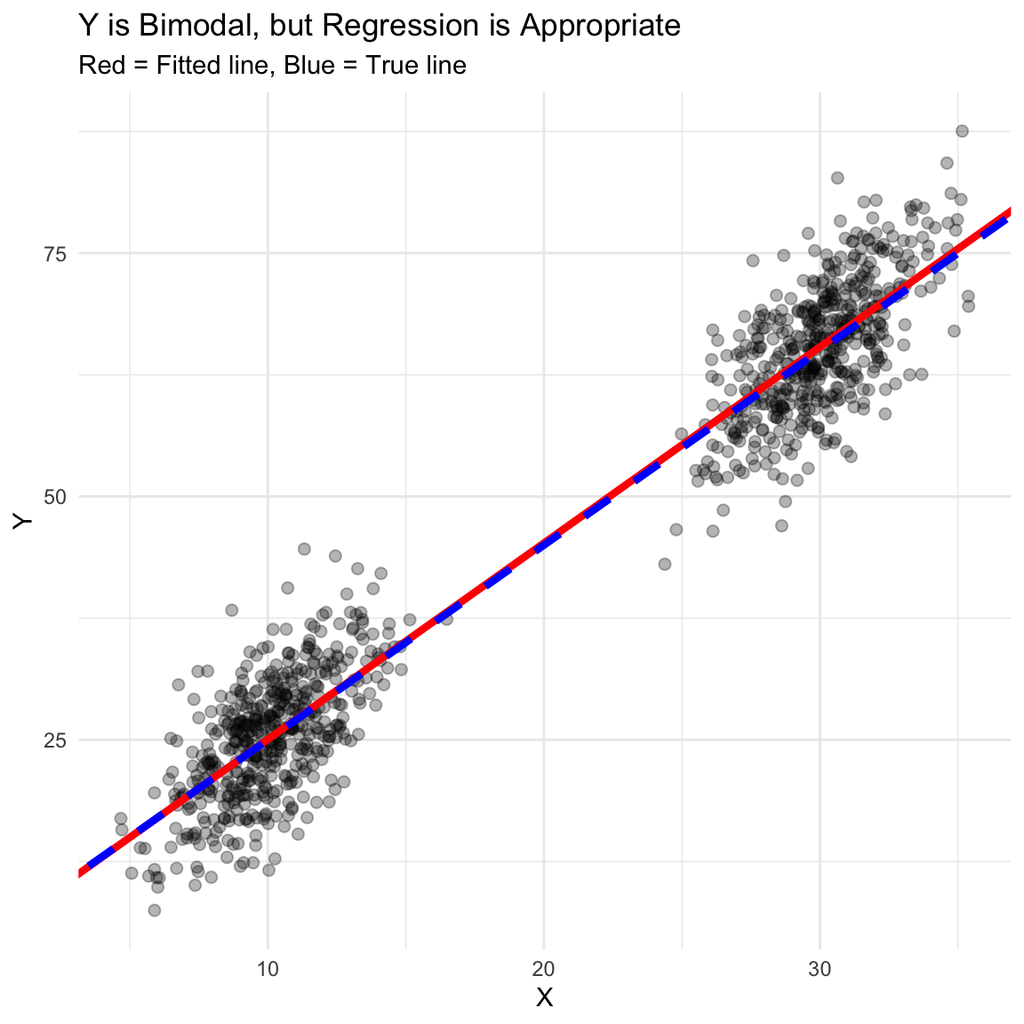

```r
ggplot(data, aes(x = X, y = Y)) +
  geom_point(alpha = 0.3, size = 2) +
  geom_abline(intercept = coef(model)[1], slope = coef(model)[2],
              color = "red", linewidth = 1.5, linetype = "solid") +
  geom_abline(intercept = true_beta0, slope = true_beta1,
              color = "blue", linewidth = 1.5, linetype = "dashed") +
  labs(title = "Y is Bimodal, but Regression is Appropriate",
       subtitle = "Red = Fitted line, Blue = True line",
       x = "X", y = "Y") +
  theme_minimal() +
  theme(legend.position = "top")
```

## Conclusion

### Key Takeaways

- **Y is clearly bimodal** (not normal) - see the histogram
- **Residuals ARE normal** - see their histogram and Q-Q plot
- **Regression is completely valid** - recovers true parameters perfectly
- **What matters**: ε ~ N(0, σ²), NOT Y ~ N(μ, σ²)

The assumption is about the **conditional distribution** of Y given X (which is the same as saying errors are normal), not the **marginal distribution** of Y.

### Final Summary

- Y is clearly bimodal (not normal)
- But residuals are normal, so regression is valid!
- **Estimated slope**: 2.0163 vs true slope: 2
- **Estimated intercept**: 4.8865 vs true intercept: 5